# R Notebook

The goal here is to use conventional alpha diversity metrics to see how Chao1 richness, shannon diversity and evenness change across samples and to compare those to the values seen using breakaway in the AlphaDiversity.Rmd file

# Setup

Run AlphaDiversity in scratchnotebooks That file calculates richness in breakawy which I will combine here

```r
#source(here::here("RScripts", "InitialProcessing_3.R"))
source(here::here("RLibraries", "ChesapeakePersonalLibrary.R"))
ksource(here::here("ActiveNotebooks", "BreakawayAlphaDiversity_Env.Rmd"))
```

```
processing file: /home/jacob/Projects/ChesapeakeMainstemAnalysis_ToShare/ActiveNotebooks/BreakawayAlphaDiversity_Env.Rmd
```

[output not shown]

```
output file: /tmp/Rtmpt2k6Q5/file56223c95dc91



Warning: Assuming taxa are rows
```

```r
library(vegan)
library(cowplot)
library(flextable)
library(ftExtra)
```

This file is dedicated to conventional, non div-net/breakaway stats, since breakaway seems to choke on this data.

Reshape back into an ASV matrix, but this time correcting for total abundance

```r
raDf <- nonSpikes_Remake %>% pivot_wider(id_cols = ID, names_from = ASV, values_from = RA, values_fill = 0)
raMat <- raDf %>% column_to_rownames("ID")
```

```r
raMat1 <- raMat %>% as.matrix()
```

```r
countMat <-  nonSpikes_Remake %>%
  pivot_wider(id_cols = ID, names_from = ASV, values_from = reads, values_fill = 0) %>%
  column_to_rownames("ID") %>% as.matrix()
```

```r
seqDep <- countMat %>% apply(1, sum)
names(seqDep) <- rownames(countMat)
min(seqDep)
```

```
[1] 852
```

This value is lower than the lowist chimera checked value because the spikes have been discarded (while chimera checked read depth still has spikes)

```r
sampleRichness <- rarefy(countMat, min(seqDep))
```

rarefy everything to the minimum depth (852)

```r
countRare <- rrarefy(countMat, min(seqDep))
```

Gamma diversity

```r
specpool(countRare)
```

|  | Species | chao | chao.se | jack1 | jack1.se | jack2 | boot | boot.se | n |
| --- | --- | --- | --- | --- | --- | --- | --- | --- | --- |
| All | 7163 | 33617.51 | 1371.502 | 12408.12 | 789.0523 | 17076.35 | 9193.05 | 332.9434 | 75 |

Doesn’t finish

```r
#specpool(countMat)
```

# Calculate diversity indeces

All richness estimates

```r
richnessRare <- estimateR(countRare)
```

Shannon diversity

```r
shan <- diversity(countRare)
shan
```

```
 3-1-B-0-2  3-1-B-1-2  3-1-B-180   3-1-B-20    3-1-B-5  3-1-B-500   3-1-B-53  3-1-S-0-2  3-1-S-1-2  3-1-S-180   3-1-S-20    3-1-S-5  3-2-B-0-2
  4.363509   5.060063   4.738357   5.942750   5.254904   3.868602   5.558963   4.577161   4.973462   4.681770   5.253723   4.832191   4.299471
 3-2-B-1-2  3-2-B-180   3-2-B-20    3-2-B-5  3-2-B-500   3-2-B-53  3-2-S-0-2  3-2-S-1-2  3-2-S-180   3-2-S-20    3-2-S-5  3-2-S-500   3-2-S-53
  4.804543   4.640980   5.032342   5.523277   4.972463   4.902495   3.698907   4.915321   4.720568   4.962321   5.259631   4.901801   4.380119
 3-3-B-0-2  3-3-B-1-2  3-3-B-180   3-3-B-20    3-3-B-5  3-3-B-500   3-3-B-53  3-3-S-180   3-3-S-20  3-3-S-500   3-3-S-53  4-3-B-0-2  4-3-B-1-2
  4.343648   4.894349   3.446375   5.763308   5.272320   5.291467   5.492510   5.033910   4.906806   4.925053   4.268437   4.341540   4.946916
 4-3-B-180   4-3-B-20    4-3-B-5  4-3-B-500   4-3-B-53  4-3-O-1-2  4-3-O-180    4-3-O-5  4-3-O-500   4-3-O-53  4-3-S-0-2  4-3-S-180   4-3-S-20
  4.411257   4.547148   4.614288   4.305526   4.188987   4.954917   4.654181   5.179688   4.059731   4.525717   2.805419   4.484527   4.575048
 4-3-S-500   4-3-S-53  5-1-S-1-2  5-1-S-180   5-1-S-20    5-1-S-5  5-1-S-500   5-1-S-53  5-5-B-0-2  5-5-B-180    5-5-B-5  5-5-B-500   5-5-B-53
  4.774040   4.366290   4.395112   4.485968   4.280011   4.026467   4.060917   4.019538   4.553517   5.097029   5.402883   5.085291   4.966698
 5-5-S-180    5-5-S-5  5-5-S-500   5-5-S-53 C_5P1B_0P2 C_5P1B_180 C_5P1B_1P2  C_5P1B_20 C_5P1B_500  C_5P1B_53
  4.350108   5.053749   4.881644   4.208389   4.349046   4.817551   4.691421   5.404041   4.715323   5.158789
```

Evenness

```r
pielouJ <- shan/richnessRare["S.chao1",]
pielouJ
```

```
  3-1-B-0-2   3-1-B-1-2   3-1-B-180    3-1-B-20     3-1-B-5   3-1-B-500    3-1-B-53   3-1-S-0-2   3-1-S-1-2   3-1-S-180    3-1-S-20     3-1-S-5
0.011768277 0.007689268 0.012667817 0.002648579 0.005746093 0.041822727 0.008495769 0.009623615 0.008875898 0.009990325 0.008228359 0.007887861
  3-2-B-0-2   3-2-B-1-2   3-2-B-180    3-2-B-20     3-2-B-5   3-2-B-500    3-2-B-53   3-2-S-0-2   3-2-S-1-2   3-2-S-180    3-2-S-20     3-2-S-5
0.011281147 0.008315628 0.013048320 0.005739685 0.005778393 0.008718221 0.010168569 0.017940491 0.010134237 0.012022862 0.007425067 0.007778702
  3-2-S-500    3-2-S-53   3-3-B-0-2   3-3-B-1-2   3-3-B-180    3-3-B-20     3-3-B-5   3-3-B-500    3-3-B-53   3-3-S-180    3-3-S-20   3-3-S-500
0.006695042 0.012531409 0.010740526 0.007007070 0.068584581 0.005085056 0.007546259 0.006570977 0.007025348 0.007908369 0.008379681 0.009281776
   3-3-S-53   4-3-B-0-2   4-3-B-1-2   4-3-B-180    4-3-B-20     4-3-B-5   4-3-B-500    4-3-B-53   4-3-O-1-2   4-3-O-180     4-3-O-5   4-3-O-500
0.011619807 0.010806217 0.007856954 0.009795538 0.008478453 0.009159138 0.008912403 0.010523060 0.008111734 0.011677051 0.006980527 0.011861511
   4-3-O-53   4-3-S-0-2   4-3-S-180    4-3-S-20   4-3-S-500    4-3-S-53   5-1-S-1-2   5-1-S-180    5-1-S-20     5-1-S-5   5-1-S-500    5-1-S-53
0.013029386 0.124685269 0.014373485 0.010651442 0.010808717 0.011995303 0.009991730 0.014892303 0.014823875 0.015834423 0.011003900 0.014376030
  5-5-B-0-2   5-5-B-180     5-5-B-5   5-5-B-500    5-5-B-53   5-5-S-180     5-5-S-5   5-5-S-500    5-5-S-53  C_5P1B_0P2  C_5P1B_180  C_5P1B_1P2
0.007599089 0.007892997 0.008660202 0.009754904 0.009695014 0.012209607 0.012167934 0.006578796 0.014122110 0.007996866 0.007674681 0.007922513
  C_5P1B_20  C_5P1B_500   C_5P1B_53
0.003234945 0.007567001 0.005305960
```

## Combine diversity data

```r
diversityData <- sampleData %>%
  left_join(richnessRare %>% t() %>% as.data.frame() %>% rownames_to_column("ID"), by = "ID") %>%
  left_join(shan %>% enframe(name = "ID", value = "shannonH"), by = "ID") %>%
  left_join(pielouJ %>% enframe(name = "ID", value = "pielouJ"), by = "ID") %>%
  arrange(Size_Class)
```

# Generate plots of diversity estimates

Parameters for all plots

```r
plotSpecs <- list(
  facet_wrap(~Depth, ncol = 1) ,
  theme_bw(base_size = 16) ,
  geom_point(size = 4) ,
  geom_path(aes(color = as.factor(Station))) ,
  scale_x_log10(breaks = my_sizes, labels = as.character(my_sizes)) ,
  #scale_y_log10nice() ,
  scale_shape_manual(values = rep(21:25, 2)) ,
  scale_fill_viridis_d(option = "plasma") ,
  scale_color_viridis_d(option = "plasma") ,
  labs(x = expression(paste("Particle Size (", mu, "m)"))) ,
  theme(legend.position = "none",
        plot.margin = unit(c(0, 0, 0, 0), "cm"),
        axis.title.x = element_blank(),
        axis.text.x = element_text(angle = 90, vjust = .5),
        axis.title.y = element_text(margin = unit(c(3, 3, 3, 3), "mm"), vjust = 0))
)
```

Observed species counts, on rarefied data

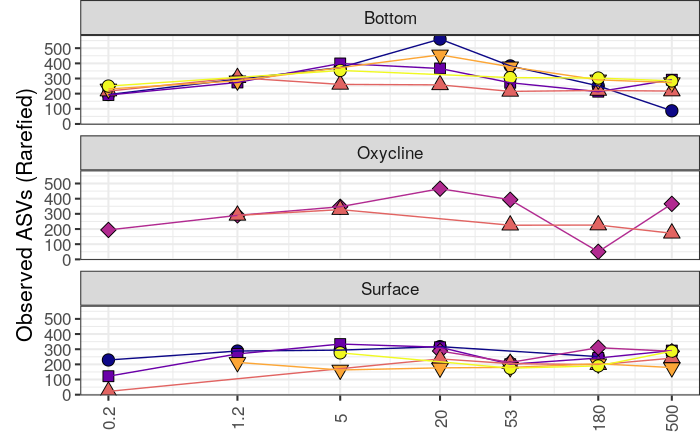

```r
plotObs <- diversityData %>%
#filter(Depth %in% c("Surface", "Bottom")) %>%
  ggplot(aes(x = Size_Class, y = S.obs, shape = as.factor(Station), fill = as.factor(Station))) +
  plotSpecs +ylab("Observed ASVs (Rarefied)")#+ scale_y_log10()
plotObs
```

Estemated Chao1 Richness

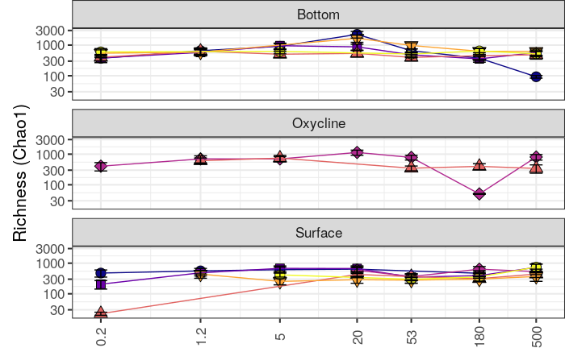

```r
plotChao1 <- diversityData %>%
#filter(Depth %in% c("Surface", "Bottom")) %>%
  ggplot(aes(x = Size_Class, y = S.chao1, shape = as.factor(Station), fill = as.factor(Station))) +
  plotSpecs +
  geom_errorbar(aes(ymin = S.chao1 -2 * se.chao1, ymax = S.chao1 + 2* se.chao1), width = -.1) +
  scale_y_log10() +
  ylab("Richness (Chao1)")
plotChao1
```

Shannon diversity

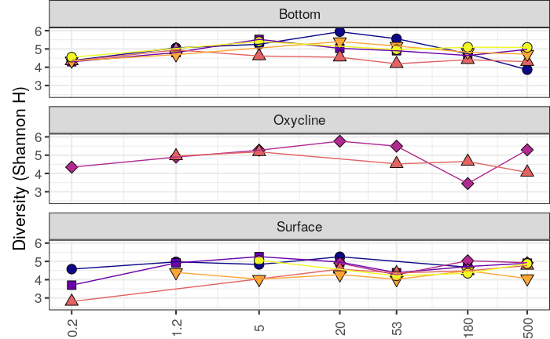

```r
plotShan <- diversityData %>%
#filter(Depth %in% c("Surface", "Bottom")) %>%
  ggplot(aes(x = Size_Class, y = shannonH, shape = as.factor(Station), fill = as.factor(Station))) +
  plotSpecs +
  ylab("Diversity (Shannon H)") +
  lims(y = c(2.5, 6))
plotShan
```

Evenness

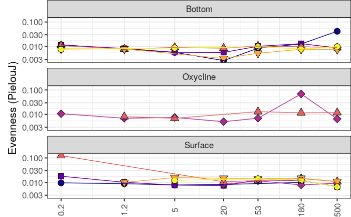

```r
plotPielou <- diversityData %>%

#filter(Depth %in% c("Surface", "Bottom")) %>%
  ggplot(aes(x = Size_Class, y = pielouJ, shape = as.factor(Station), fill = as.factor(Station))) +
  plotSpecs +scale_y_log10() +ylab("Evenness (PielouJ)")
plotPielou
```

All plots together

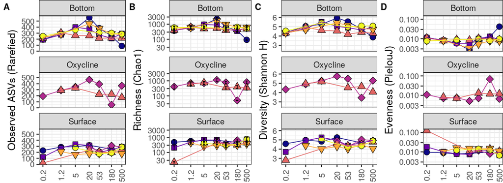

```r
plotAlpha <- plot_grid(plotObs, plotChao1, plotShan, plotPielou, nrow = 1, labels = LETTERS)
plotAlpha
```

```r
ggsave(here::here("Figures", "ConventionalAlpha.png"), plotAlpha, width = 11, height = 4)
```

## Observed Species

Rarefied observed species numbers

```r
obsMod <- lm(S.obs ~ log10(Size_Class) + I(log10(Size_Class)^2)  + Salinity + I(Salinity^2) + log10(Oxygen + 0.03), data = diversityData)
summary(obsMod)
```

```
Call:
lm(formula = S.obs ~ log10(Size_Class) + I(log10(Size_Class)^2) +
    Salinity + I(Salinity^2) + log10(Oxygen + 0.03), data = diversityData)

Residuals:
     Min       1Q   Median       3Q      Max
-201.531  -44.122   -2.128   49.487  222.349

Coefficients:
                       Estimate Std. Error t value Pr(>|t|)
(Intercept)            348.9548    32.1411  10.857  < 2e-16 ***
log10(Size_Class)       83.7977    18.5579   4.515 2.54e-05 ***
I(log10(Size_Class)^2) -36.1262     7.9187  -4.562 2.14e-05 ***
Salinity               -14.0515     7.1867  -1.955   0.0546 .
I(Salinity^2)            0.4391     0.3821   1.149   0.2544
log10(Oxygen + 0.03)   -40.2742    31.8469  -1.265   0.2103
---
Signif. codes:  0 ‘***’ 0.001 ‘**’ 0.01 ‘*’ 0.05 ‘.’ 0.1 ‘ ’ 1

Residual standard error: 75.4 on 69 degrees of freedom
Multiple R-squared:  0.3107,    Adjusted R-squared:  0.2607
F-statistic: 6.219 on 5 and 69 DF,  p-value: 8.14e-05
```

## Richness

Rarified chao1 estimates

```r
chao1Mod <- lm(S.chao1 ~ log10(Size_Class) + I(log10(Size_Class)^2)  + Salinity + I(Salinity^2) + log10(Oxygen + 0.03), data = diversityData)
summary(chao1Mod)
```

```
Call:
lm(formula = S.chao1 ~ log10(Size_Class) + I(log10(Size_Class)^2) +
    Salinity + I(Salinity^2) + log10(Oxygen + 0.03), data = diversityData)

Residuals:
    Min      1Q  Median      3Q     Max
-451.35 -160.62  -50.73  108.57 1480.91

Coefficients:
                       Estimate Std. Error t value Pr(>|t|)
(Intercept)             849.470    123.441   6.882 2.18e-09 ***
log10(Size_Class)       213.164     71.273   2.991  0.00386 **
I(log10(Size_Class)^2)  -95.099     30.412  -3.127  0.00259 **
Salinity                -44.942     27.601  -1.628  0.10803
I(Salinity^2)             1.359      1.467   0.926  0.35770
log10(Oxygen + 0.03)   -149.868    122.311  -1.225  0.22463
---
Signif. codes:  0 ‘***’ 0.001 ‘**’ 0.01 ‘*’ 0.05 ‘.’ 0.1 ‘ ’ 1

Residual standard error: 289.6 on 69 degrees of freedom
Multiple R-squared:  0.2074,    Adjusted R-squared:   0.15
F-statistic: 3.612 on 5 and 69 DF,  p-value: 0.00584
```

As above but without salinity and oxygen

```r
chao1ModSimple <- lm(S.chao1 ~ log10(Size_Class) + I(log10(Size_Class)^2), data = diversityData)
summary(chao1ModSimple)
```

```
Call:
lm(formula = S.chao1 ~ log10(Size_Class) + I(log10(Size_Class)^2),
    data = diversityData)

Residuals:
    Min      1Q  Median      3Q     Max
-483.67 -168.75  -24.17  103.90 1579.19

Coefficients:
                       Estimate Std. Error t value Pr(>|t|)
(Intercept)              572.82      53.87  10.634  < 2e-16 ***
log10(Size_Class)        190.17      73.66   2.582  0.01186 *
I(log10(Size_Class)^2)   -91.97      31.55  -2.915  0.00474 **
---
Signif. codes:  0 ‘***’ 0.001 ‘**’ 0.01 ‘*’ 0.05 ‘.’ 0.1 ‘ ’ 1

Residual standard error: 301.1 on 72 degrees of freedom
Multiple R-squared:  0.1057,    Adjusted R-squared:  0.08088
F-statistic: 4.256 on 2 and 72 DF,  p-value: 0.01791
```

## Shannon Diversity

```r
shanMod <- lm(shannonH ~ log10(Size_Class) + I(log10(Size_Class)^2) + Salinity + I(Salinity^2) + log10(Oxygen + 0.03), data = diversityData )
```

```r
summary(shanMod)
```

```
Call:
lm(formula = shannonH ~ log10(Size_Class) + I(log10(Size_Class)^2) +
    Salinity + I(Salinity^2) + log10(Oxygen + 0.03), data = diversityData)

Residuals:
     Min       1Q   Median       3Q      Max
-1.24185 -0.26214  0.03001  0.33763  0.85667

Coefficients:
                        Estimate Std. Error t value Pr(>|t|)
(Intercept)             5.193944   0.195165  26.613  < 2e-16 ***
log10(Size_Class)       0.502696   0.112686   4.461 3.09e-05 ***
I(log10(Size_Class)^2) -0.205712   0.048083  -4.278 5.95e-05 ***
Salinity               -0.094904   0.043639  -2.175   0.0331 *
I(Salinity^2)           0.003215   0.002320   1.386   0.1702
log10(Oxygen + 0.03)   -0.142785   0.193379  -0.738   0.4628
---
Signif. codes:  0 ‘***’ 0.001 ‘**’ 0.01 ‘*’ 0.05 ‘.’ 0.1 ‘ ’ 1

Residual standard error: 0.4578 on 69 degrees of freedom
Multiple R-squared:  0.2864,    Adjusted R-squared:  0.2347
F-statistic: 5.539 on 5 and 69 DF,  p-value: 0.00024
```

## Evenness

```r
pielouMod <- lm(pielouJ ~ log10(Size_Class) + I(log10(Size_Class)^2) + Salinity + I(Salinity^2) + log10(Oxygen + 0.03), data = diversityData)
summary(pielouMod)
```

```
Call:
lm(formula = pielouJ ~ log10(Size_Class) + I(log10(Size_Class)^2) +
    Salinity + I(Salinity^2) + log10(Oxygen + 0.03), data = diversityData)

Residuals:
      Min        1Q    Median        3Q       Max
-0.014597 -0.005373 -0.001650  0.001588  0.098014

Coefficients:
                         Estimate Std. Error t value Pr(>|t|)
(Intercept)             5.951e-03  6.413e-03   0.928   0.3567
log10(Size_Class)      -9.218e-03  3.703e-03  -2.489   0.0152 *
I(log10(Size_Class)^2)  3.508e-03  1.580e-03   2.220   0.0297 *
Salinity                1.070e-03  1.434e-03   0.746   0.4582
I(Salinity^2)          -2.933e-05  7.624e-05  -0.385   0.7016
log10(Oxygen + 0.03)    6.407e-03  6.355e-03   1.008   0.3168
---
Signif. codes:  0 ‘***’ 0.001 ‘**’ 0.01 ‘*’ 0.05 ‘.’ 0.1 ‘ ’ 1

Residual standard error: 0.01504 on 69 degrees of freedom
Multiple R-squared:  0.1237,    Adjusted R-squared:  0.06021
F-statistic: 1.948 on 5 and 69 DF,  p-value: 0.09746
```

# Prediction plots

## Observed Species

```r
predict(obsMod, se.fit = TRUE)
```

```
$fit
       1        2        3        4        5        6        7        8        9       10       11       12       13       14       15       16
213.5560 231.1275 183.6467 184.3555 170.0697 213.4423 147.8545 217.7890 188.3297 296.1866 313.7581 266.2773 266.9861 252.7003 296.0728 238.5527
      17       18       19       20       21       22       23       24       25       26       27       28       29       30       31       32
300.4196 224.7464 330.7002 348.2716 300.7908 301.4996 287.2139 330.5864 273.0663 259.2600 305.4738 246.5783 337.6511 355.2226 307.7418 308.4506
      33       34       35       36       37       38       39       40       41       42       43       44       45       46       47       48
294.1648 299.0179 337.5374 271.9496 341.8841 266.2109 326.8604 296.9511 297.6599 283.3741 288.2272 326.7467 269.2266 261.1589 331.0934 255.4203
      49       50       51       52       53       54       55       56       57       58       59       60       61       62       63       64
301.6341 242.7386 295.0175 312.5890 265.1082 265.8170 251.5312 256.3842 294.9038 237.3836 229.3160 299.2505 223.5773 269.7911 210.8957 252.7863
      65       66       67       68       69       70       71       72       73       74       75
222.8769 223.5857 209.2999 214.1530 252.6725 195.1524 187.0848 257.0192 181.3461 227.5599 168.6644

$se.fit
 [1] 26.80076 30.38829 29.77120 24.18774 24.61836 27.69235 27.04157 27.79995 31.40200 19.29633 24.34911 22.76778 14.65161 14.96787 21.21220
[16] 17.86557 21.49438 19.64542 19.77261 24.93877 22.88255 14.70670 14.71643 21.81772 17.44672 18.97680 25.52986 25.11108 19.91978 25.22753
[31] 22.80367 14.41284 14.11955 14.77554 21.81250 16.64662 22.12002 17.97663 19.36620 22.21954 13.30796 12.75726 13.49212 21.02194 15.37596
[46] 15.13801 21.29867 16.47829 24.00715 22.80755 20.11448 25.59043 22.80305 14.03402 13.23650 13.94568 21.14477 15.51008 15.05831 21.32788
[61] 16.24316 23.60011 22.32518 24.90602 27.11172 20.14477 19.44177 19.92184 25.19206 20.87758 20.40986 25.25270 21.18146 26.87632 25.88447

$df
[1] 69

$residual.scale
[1] 75.39678
```

```r
diversityData$pred_obs = predict(obsMod, se.fit = TRUE)$fit
diversityData$se_obs = predict(obsMod, se.fit = TRUE)$se.fit
```

```r
plotSpecs2 <- list(
  facet_wrap(~Depth, ncol = 1) ,
  theme_bw(base_size = 16) ,
  #geom_point(size = 4) ,
  geom_path(aes(color = as.factor(Station))) ,
  scale_x_log10(breaks = my_sizes, labels = as.character(my_sizes)) ,
  #scale_y_log10nice() ,
  scale_shape_manual(values = rep(21:25, 2)) ,
  scale_fill_viridis_d(option = "plasma") ,
  scale_color_viridis_d(option = "plasma") ,
  labs(x = expression(paste("Particle Size (", mu, "m)"))) ,
  theme(legend.position = "none",
        plot.margin = unit(c(0, 0, 0, 0), "cm"),
        axis.title.x = element_blank(),
        axis.text.x = element_text(angle = 90, vjust = .5),
        axis.title.y = element_text(margin = unit(c(3, 3, 3, 3), "mm"), vjust = 0))
)
```

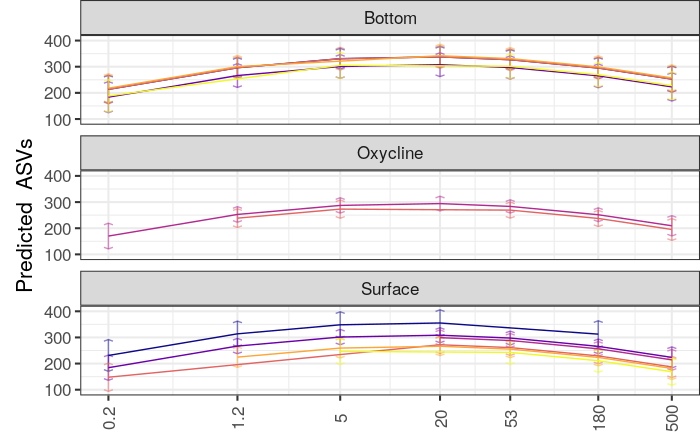

```r
plotObs_pred <-  diversityData %>%
#filter(Depth %in% c("Surface", "Bottom")) %>%
  ggplot(aes(x = Size_Class, y = pred_obs, shape = as.factor(Station), fill = as.factor(Station))) +
  geom_segment(aes(y = pred_obs - 2 * se_obs, yend = pred_obs + 2 * se_obs, xend = Size_Class, color = as.factor(Station)), arrow = arrow(angle = 70, length = unit(0.05, "in"), ends = "both"), alpha = 0.5)  +
  plotSpecs2 + ylab("Predicted  ASVs")
plotObs_pred
```

## Richness

```r
predict(chao1Mod, se.fit = TRUE)
```

```
$fit
       1        2        3        4        5        6        7        8        9       10       11       12       13       14       15       16
451.0186 508.3396 363.3533 356.7517 309.0945 471.3682 233.6555 484.6852 376.6125 662.7571 720.0781 575.0918 568.4902 520.8331 683.1068 477.7351
      17       18       19       20       21       22       23       24       25       26       27       28       29       30       31       32
696.4237 426.8147 749.0084 806.3294 661.3431 654.7415 607.0844 769.3581 563.9864 513.0660 674.6024 467.6096 762.8355 820.1565 675.1702 668.5686
      33       34       35       36       37       38       39       40       41       42       43       44       45       46       47       48
620.9114 634.0231 783.1852 545.4724 796.5021 526.8930 731.2872 643.6219 637.0203 589.3631 602.4748 751.6369 546.2652 513.9241 764.9538 495.3447
      49       50       51       52       53       54       55       56       57       58       59       60       61       62       63       64
656.8812 449.8884 643.5209 700.8419 555.8556 549.2539 501.5968 514.7085 663.8705 458.4989 426.1578 677.1875 407.5784 569.1148 362.1221 529.0566
      65       66       67       68       69       70       71       72       73       74       75
441.3913 434.7897 387.1325 400.2442 549.4063 344.0346 311.6935 562.7232 293.1141 454.6505 247.6578

$se.fit
 [1] 102.93091 116.70916 114.33919  92.89536  94.54918 106.35513 103.85576 106.76838 120.60241  74.10941  93.51512  87.44186  56.27091  57.48557
[15]  81.46751  68.61445  82.55125  75.45013  75.93861  95.77977  87.88263  56.48251  56.51986  83.79305  67.00583  72.88224  98.04988  96.44154
[29]  76.50385  96.88877  87.57969  55.35393  54.22748  56.74691  83.77300  63.93294  84.95407  69.04101  74.37776  85.33629  51.11052  48.99549
[43]  51.81779  80.73679  59.05287  58.13899  81.79959  63.28646  92.20179  87.59462  77.25159  98.28251  87.57734  53.89900  50.83606  53.55972
[57]  81.20852  59.56795  57.83288  81.91180  62.38341  90.63851  85.74202  95.65398 104.12518  77.36792  74.66799  76.51176  96.75254  80.18237
[71]  78.38603  96.98543  81.34946 103.22109  99.41183

$df
[1] 69

$residual.scale
[1] 289.5686
```

```r
diversityData$pred_chao1 = predict(chao1Mod, se.fit = TRUE)$fit
diversityData$se_chao1 = predict(chao1Mod, se.fit = TRUE)$se.fit
```

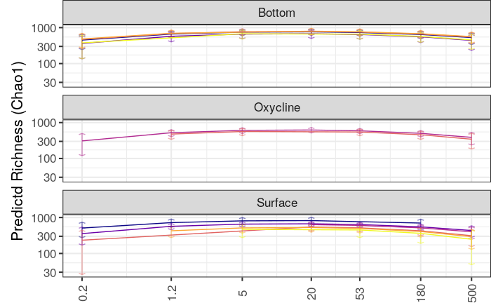

```r
plotChao1_pred <-  diversityData %>%

#filter(Depth %in% c("Surface", "Bottom")) %>%
  ggplot(aes(x = Size_Class, y = pred_chao1, shape = as.factor(Station), fill = as.factor(Station))) +
  geom_segment(aes(y = pred_chao1 - 2 * se_chao1, yend = pred_chao1 + 2 * se_chao1, xend = Size_Class, color = as.factor(Station)), arrow = arrow(angle = 70, length = unit(0.05, "in"), ends = "both"), alpha = 0.5)  +
  plotSpecs2 + ylab("Predictd Richness (Chao1)") + scale_y_log10()
plotChao1_pred
```

## Shannon Diversity

```r
predict(shanMod, se.fit = TRUE)
```

```
$fit
       1        2        3        4        5        6        7        8        9       10       11       12       13       14       15       16
4.426419 4.538373 4.173647 4.233873 4.148945 4.287019 4.024637 4.319035 4.205572 4.916805 5.028760 4.664034 4.724260 4.639331 4.777406 4.528679
      17       18       19       20       21       22       23       24       25       26       27       28       29       30       31       32
4.809422 4.476746 5.129158 5.241112 4.876386 4.936612 4.851684 4.989758 4.741032 4.689099 4.908311 4.632206 5.184109 5.296064 4.931338 4.991564
      33       34       35       36       37       38       39       40       41       42       43       44       45       46       47       48
4.906635 4.954670 5.044710 4.782328 5.076726 4.744050 5.133470 4.880698 4.940924 4.855996 4.904031 4.994070 4.745343 4.731688 5.026086 4.693411
      49       50       51       52       53       54       55       56       57       58       59       60       61       62       63       64
4.912622 4.636517 4.965704 5.077659 4.712932 4.773159 4.688230 4.736265 4.826305 4.577578 4.563923 4.858321 4.525645 4.744857 4.468752 4.736556
      65       66       67       68       69       70       71       72       73       74       75
4.483784 4.544011 4.459082 4.507117 4.597157 4.348430 4.334775 4.629173 4.296497 4.515709 4.239604

$se.fit
 [1] 0.16273800 0.18452198 0.18077496 0.14687137 0.14948614 0.16815183 0.16420022 0.16880520 0.19067736 0.11717002 0.14785124 0.13824917 0.08896661
[14] 0.09088704 0.12880348 0.10848226 0.13051692 0.11928975 0.12006205 0.15143175 0.13894605 0.08930117 0.08936022 0.13248025 0.10593897 0.11522981
[27] 0.15502089 0.15247804 0.12095572 0.15318512 0.13846709 0.08751683 0.08573587 0.08971919 0.13244855 0.10108060 0.13431587 0.10915667 0.11759430
[40] 0.13492018 0.08080783 0.07746388 0.08192605 0.12764818 0.09336502 0.09192013 0.12932850 0.10005850 0.14577482 0.13849069 0.12213794 0.15538868
[53] 0.13846337 0.08521653 0.08037390 0.08468012 0.12839401 0.09417938 0.09143616 0.12950592 0.09863074 0.14330321 0.13556165 0.15123287 0.16462618
[66] 0.12232186 0.11805316 0.12096824 0.15296973 0.12677161 0.12393153 0.15333795 0.12861683 0.16319679 0.15717419

$df
[1] 69

$residual.scale
[1] 0.4578199
```

```r
diversityData$pred_shanH = predict(shanMod, se.fit = TRUE)$fit
diversityData$se_shanH = predict(shanMod, se.fit = TRUE)$se.fit
```

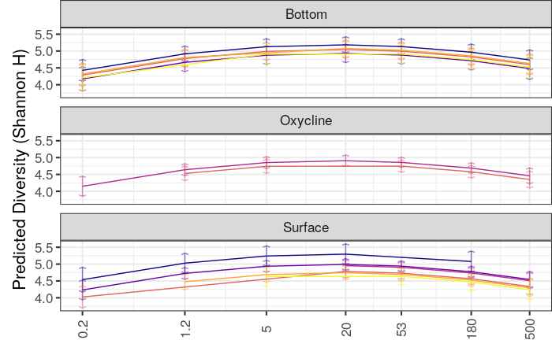

```r
plotShannonH_pred <- diversityData %>%

 #filter(Depth %in% c("Surface", "Bottom")) %>%
  ggplot(aes(x = Size_Class, y = pred_shanH, shape = as.factor(Station), fill = as.factor(Station))) +
  geom_segment(aes(y = pred_shanH - 2 * se_shanH, yend = pred_shanH + 2 * se_shanH, xend = Size_Class, color = as.factor(Station)), arrow = arrow(angle = 70, length = unit(0.05, "in"), ends = "both"),  alpha = 0.5)  +
  plotSpecs2 + ylab("Predicted Diversity (Shannon H)") #+ scale_y_log10()
plotShannonH_pred
```

## Evenness

```r
predict(pielouMod, se.fit = TRUE)
```

```
$fit
          1           2           3           4           5           6           7           8           9          10          11          12
0.020769682 0.019269991 0.021602569 0.023060780 0.024407625 0.016293306 0.026671477 0.015957730 0.020450459 0.011904510 0.010404818 0.012737396
         13          14          15          16          17          18          19          20          21          22          23          24
0.014195607 0.015542453 0.007428134 0.016080828 0.007092558 0.018185318 0.007882962 0.006383271 0.008715849 0.010174060 0.011520905 0.003406586
         25          26          27          28          29          30          31          32          33          34          35          36
0.012059281 0.014163771 0.007563739 0.015771991 0.006557056 0.005057364 0.007389942 0.008848153 0.010194999 0.010256312 0.002080680 0.012458850
         37          38          39          40          41          42          43          44          45          46          47          48
0.001745104 0.012837865 0.007147286 0.007980172 0.009438383 0.010785229 0.010846542 0.002670910 0.011323604 0.013049080 0.002335334 0.013428095
         49          50          51          52          53          54          55          56          57          58          59          60
0.006828063 0.015036315 0.009665300 0.008165609 0.010498187 0.011956398 0.013303244 0.013364557 0.005188924 0.013841619 0.015567095 0.004853349
         61          62          63          64          65          66          67          68          69          70          71          72
0.015946109 0.009346078 0.017554330 0.013286458 0.014119345 0.015577556 0.016924401 0.016985715 0.008810082 0.017462777 0.019188253 0.008474506
         73          74          75
0.019567267 0.012967235 0.021175487

$se.fit
 [1] 0.005347818 0.006063673 0.005940540 0.004826417 0.004912342 0.005525725 0.005395869 0.005547196 0.006265948 0.003850385 0.004858617
[12] 0.004543078 0.002923578 0.002986687 0.004232678 0.003564892 0.004288985 0.003920043 0.003945422 0.004976278 0.004565979 0.002934572
[23] 0.002936513 0.004353503 0.003481316 0.003786627 0.005094222 0.005010660 0.003974789 0.005033896 0.004550239 0.002875936 0.002817411
[34] 0.002948309 0.004352461 0.003321662 0.004413824 0.003587054 0.003864328 0.004433682 0.002655468 0.002545581 0.002692215 0.004194713
[45] 0.003068117 0.003020636 0.004249932 0.003288075 0.004790383 0.004551015 0.004013639 0.005106308 0.004550117 0.002800345 0.002641209
[56] 0.002782718 0.004219223 0.003094878 0.003004731 0.004255762 0.003241156 0.004709162 0.004454762 0.004969742 0.005409867 0.004019683
[67] 0.003879407 0.003975201 0.005026818 0.004165908 0.004072579 0.005038919 0.004226545 0.005362895 0.005164983

$df
[1] 69

$residual.scale
[1] 0.01504466
```

```r
diversityData$pred_pielouJ = predict(pielouMod, se.fit = TRUE)$fit
diversityData$se_pielouJ = predict(pielouMod, se.fit = TRUE)$se.fit
```

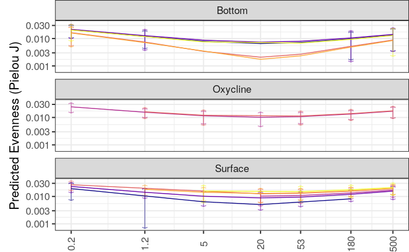

```r
plot_pielouJ_pred <- diversityData %>%

#filter(Depth %in% c("Surface", "Bottom")) %>%
  ggplot(aes(x = Size_Class, y = pred_pielouJ, shape = as.factor(Station), fill = as.factor(Station))) +
  geom_segment(aes(y = pred_pielouJ - 2 * se_pielouJ, yend = pred_pielouJ + 2 * se_pielouJ, xend = Size_Class, color = as.factor(Station), alpha = 0.5), arrow = arrow(angle = 70, length = unit(0.05, "in"), ends = "both"))  +
  plotSpecs2 + ylab("Predicted Evenness (Pielou J)") + scale_y_log10()
plot_pielouJ_pred
```

## Combined prediction plot

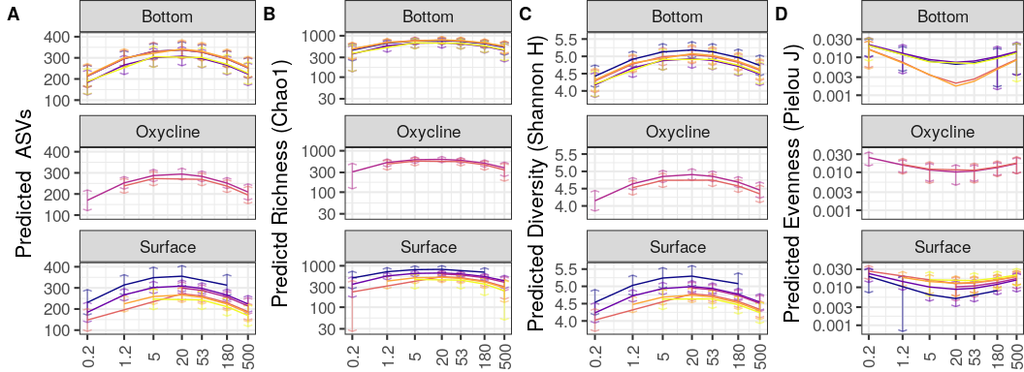

```r
plotPredictions <- plot_grid(plotObs_pred, plotChao1_pred, plotShannonH_pred, plot_pielouJ_pred, nrow = 1, labels = LETTERS)
plotPredictions
```

```r
ggsave(here::here("Figures", "ConventionalAlphaPredictions_Env.png"), plotPredictions, width = 11, height = 4)
```

## Even combindeder

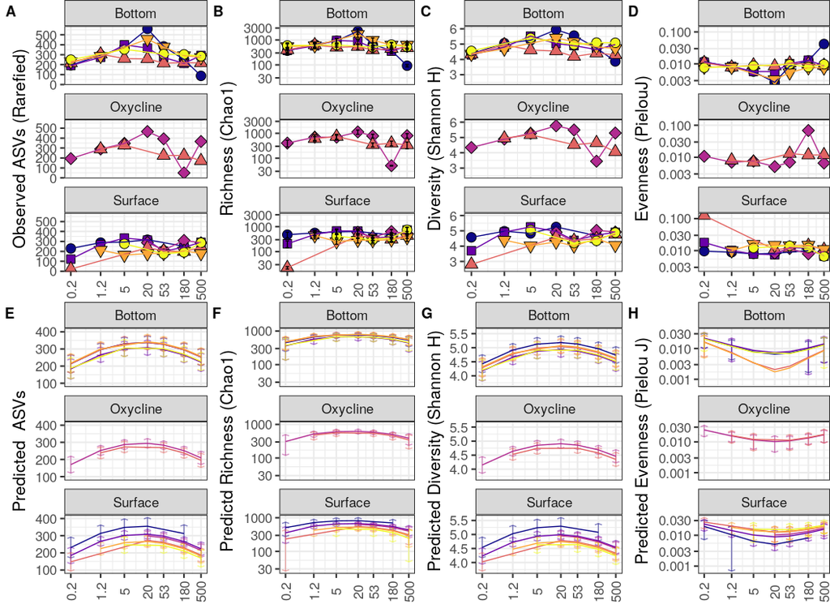

```r
plot_grid(plotObs, plotChao1, plotShan, plotPielou,
          plotObs_pred, plotChao1_pred, plotShannonH_pred, plot_pielouJ_pred,
          nrow = 2, labels = LETTERS)
```

# Combined summary table

```r
alphaSummary <- tibble(
  metric = c("Observed ASVs", "Richness (Chao1)", "Diversity (Shannon H)", "Evenness (Pielou J)"),
  model = list(obsMod, chao1Mod, shanMod, pielouMod)
)

alphaSummary <- alphaSummary %>%
  mutate(df = map(model, ~broom::tidy(summary(.))))

alphaSummary <- alphaSummary %>%
  select(-model) %>%
  unnest(df)

alphaSummary <- alphaSummary %>%
  rename(Metric = metric, Term = term, Estimate = estimate, `Standard Error` = std.error, `T Value` = statistic, p = p.value) %>%
  mutate(Term = str_replace(Term, "^I?\\((.*)\\)", "\\1"),
         Term = str_replace(Term, "\\^2", "\\^2\\^"),
         Term = str_replace(Term, "depth", "Depth"),
         Term = str_replace(Term, "lat", "Latitude"),
         Term = str_replace(Term, "_", " ")# BOOKMARK!!
         ) %>%
  mutate(Estimate = format(Estimate, digits = 2, scientific = TRUE) %>%
           reformat_sci()
         ) %>%
  mutate(`Standard Error` = format(`Standard Error`, digits = 2, scientific = TRUE) %>%
           reformat_sci()
  ) %>%
  mutate(`T Value` = format(`T Value`, digits = 2, scientific = FALSE)) %>%
  mutate(p = if_else(p < 0.001, "< 0.001", format(round(p, digits = 3)))) %>%
  rename(`Standard\nError` = `Standard Error`) %>%
  identity()

alphaSummary %>% flextable() %>% merge_v(j = 1) %>% theme_vanilla() %>%
  bold(i = ~ p< 0.05, j = "p") %>%
  colformat_md() %>%
  set_table_properties(layout = "autofit") %>%
  align(j = -c(1:2), align = "right")
```

| Metric | Term | Estimate | Standard Error | T Value | p |
| --- | --- | --- | --- | --- | --- |
| Observed ASVs | Intercept | 3.5 x 102 | 3.2 x 101 | 10.86 | < 0.001 |
|  | log10(Size Class) | 8.4 x 101 | 1.9 x 101 | 4.52 | < 0.001 |
|  | log10(Size Class)2 | -3.6 x 101 | 7.9 x 100 | -4.56 | < 0.001 |
|  | Salinity | -1.4 x 101 | 7.2 x 100 | -1.96 | 0.055 |
|  | Salinity2 | 4.4 x 10-1 | 3.8 x 10-1 | 1.15 | 0.254 |
|  | log10(Oxygen + 0.03) | -4.0 x 101 | 3.2 x 101 | -1.26 | 0.210 |
| Richness (Chao1) | Intercept | 8.5 x 102 | 1.2 x 102 | 6.88 | < 0.001 |
|  | log10(Size Class) | 2.1 x 102 | 7.1 x 101 | 2.99 | 0.004 |
|  | log10(Size Class)2 | -9.5 x 101 | 3.0 x 101 | -3.13 | 0.003 |
|  | Salinity | -4.5 x 101 | 2.8 x 101 | -1.63 | 0.108 |
|  | Salinity2 | 1.4 x 100 | 1.5 x 100 | 0.93 | 0.358 |
|  | log10(Oxygen + 0.03) | -1.5 x 102 | 1.2 x 102 | -1.23 | 0.225 |
| Diversity (Shannon H) | Intercept | 5.2 x 100 | 2.0 x 10-1 | 26.61 | < 0.001 |
|  | log10(Size Class) | 5.0 x 10-1 | 1.1 x 10-1 | 4.46 | < 0.001 |
|  | log10(Size Class)2 | -2.1 x 10-1 | 4.8 x 10-2 | -4.28 | < 0.001 |
|  | Salinity | -9.5 x 10-2 | 4.4 x 10-2 | -2.17 | 0.033 |
|  | Salinity2 | 3.2 x 10-3 | 2.3 x 10-3 | 1.39 | 0.170 |
|  | log10(Oxygen + 0.03) | -1.4 x 10-1 | 1.9 x 10-1 | -0.74 | 0.463 |
| Evenness (Pielou J) | Intercept | 6.0 x 10-3 | 6.4 x 10-3 | 0.93 | 0.357 |
|  | log10(Size Class) | -9.2 x 10-3 | 3.7 x 10-3 | -2.49 | 0.015 |
|  | log10(Size Class)2 | 3.5 x 10-3 | 1.6 x 10-3 | 2.22 | 0.030 |
|  | Salinity | 1.1 x 10-3 | 1.4 x 10-3 | 0.75 | 0.458 |
|  | Salinity2 | -2.9 x 10-5 | 7.6 x 10-5 | -0.38 | 0.702 |
|  | log10(Oxygen + 0.03) | 6.4 x 10-3 | 6.4 x 10-3 | 1.01 | 0.317 |

# Now considering breakaway values

```r
richSummary %>% rename_(.dots = setNames(names(.), paste0('break_', names(.))))
```

| break_estimate | break_error | break_lower | break_upper | break_sample_names | break_name | break_model |
| --- | --- | --- | --- | --- | --- | --- |
| 1149.49504 | 74.215916 | 840.37860 | 9.856215e+03 | 3-1-B-0-2 | breakaway | Negative Binomial |
| 3759.74532 | 600.496435 | 2190.46255 | 1.549200e+05 | 3-1-B-1-2 | breakaway | Kemp |
| 852.96618 | 95.814707 | 626.33788 | 1.070146e+04 | 3-1-B-180 | breakaway | Kemp |
| 8590.39015 | 367.922431 | 4335.69492 | 1.720644e+05 | 3-1-B-20 | breakaway | Kemp |
| 2272.34292 | 128.244212 | 1422.82197 | 2.732167e+04 | 3-1-B-5 | breakaway | Kemp |
| 100.14731 | 9.881637 | 87.75180 | 3.169175e+02 | 3-1-B-500 | breakaway | Negative Binomial |
| 2104.54130 | 197.020727 | 1259.66143 | 4.120062e+04 | 3-1-B-53 | breakaway | Kemp |
| 2274.51944 | 342.357498 | 1130.16308 | 7.971937e+04 | 3-1-S-0-2 | breakaway | Kemp |
| 3711.49178 | 372.223587 | 1937.21385 | 1.096785e+05 | 3-1-S-1-2 | breakaway | Kemp |
| 3936.99093 | 995.618813 | 2130.27993 | 2.515435e+05 | 3-1-S-180 | breakaway | Kemp |

[output cut: 65 more lines]

```r
diversityDataWB <- full_join(diversityData,
                             richSummary %>% rename_(.dots = setNames(names(.), paste0('break_', names(.)))),
                             by = c("ID" = "break_sample_names"), suffix = c("", "_break")) %>%
  mutate(pielouJ2 = shannonH/break_estimate) %>%
  identity()
```

```r
diversityDataWB
```

| ID | copiesPerL | Station | Size_Class | Depth | Bin_Size | DNAperLiter | MassperLiter | ParticlesPerLiter | Flag | δ13CVPDB (‰) | δ15NAir (‰) | CarbonPerLiter_mg | NitrogenPerLiter_mg | Depth_m | Temperature | Salinity | Oxygen | Fluorescence | PAR | pH | lat | long | UTMX | UTMY | depth | do | Depth2 | S.obs | S.chao1 | … |
| --- | --- | --- | --- | --- | --- | --- | --- | --- | --- | --- | --- | --- | --- | --- | --- | --- | --- | --- | --- | --- | --- | --- | --- | --- | --- | --- | --- | --- | --- | --- |
| 3-1-B-0-2 | 4.968996e+08 | 3.1 | 0.2 | Bottom | 1.0 | 3.037500e+03 | NA | NA | FALSE | NA | NA | NA | NA | 7.0 | 28.67496 | 2.595564 | 4.30725778 | 1.9354067 | 0.02845996 | 7.657844 | 39.24950 | -76.24050 | 392959 | 4345197 | 13.3 | 85 | NotSurface | 194 | 370.7857 | … |
| 3-1-S-0-2 | 7.688621e+08 | 3.1 | 0.2 | Surface | 1.0 | 3.690476e+03 | NA | NA | FALSE | NA | NA | NA | NA | 3.0 | 28.88710 | 1.309420 | 3.90454898 | 1.9880367 | 8.56664490 | 7.918184 | 39.24950 | -76.24050 | 392959 | 4345197 | 13.3 | 85 | Surface | 229 | 475.6176 | … |
| 3-2-B-0-2 | 1.221752e+09 | 3.2 | 0.2 | Bottom | 1.0 | 4.647059e+03 | NA | NA | FALSE | NA | NA | NA | NA | 7.0 | 27.51617 | 7.895728 | 1.34046739 | 1.6939457 | 0.01273587 | 7.672500 | 39.16369 | -76.30631 | 387143 | 4335754 | 12.2 | 54 | NotSurface | 191 | 381.1200 | … |
| 3-2-S-0-2 | 1.642566e+09 | 3.2 | 0.2 | Surface | 1.0 | 3.625000e+03 | NA | NA | FALSE | NA | NA | NA | NA | 3.0 | 28.21413 | 5.391554 | 4.23788913 | 2.4661370 | 3.93922717 | 7.917870 | 39.16369 | -76.30631 | 387143 | 4335754 | 12.2 | 54 | Surface | 122 | 206.1765 | … |
| 3-3-B-0-2 | 9.999237e+08 | 3.3 | 0.2 | Oxycline | 1.0 | 1.839286e+03 | NA | NA | FALSE | NA | NA | NA | NA | 7.0 | 28.91929 | 6.767270 | 4.83748261 | 3.0308065 | 0.01259917 | 8.394435 | 38.99596 | -76.35967 | 382254 | 4317207 | 24.1 | 10 | NotSurface | 194 | 404.4167 | … |
| 4-3-B-0-2 | 6.977776e+08 | 4.3 | 0.2 | Bottom | 1.0 | 1.589286e+03 | NA | NA | FALSE | NA | NA | NA | NA | 19.0 | 23.40519 | 19.681290 | 0.03736044 | 0.5182604 | 0.01260256 | 7.612549 | 38.55505 | -76.42794 | 375578 | 4268368 | 27.1 | 8 | NotSurface | 217 | 401.7632 | … |
| 4-3-S-0-2 | 1.625097e+07 | 4.3 | 0.2 | Surface | 1.0 | 6.875000e+03 | NA | NA | FALSE | NA | NA | NA | NA | 3.0 | 29.55167 | 9.220331 | 6.43551556 | 2.5768711 | 5.49693556 | 8.723911 | 38.55505 | -76.42794 | 375578 | 4268368 | 27.1 | 8 | Surface | 22 | 22.5000 | … |
| C_5P1B_0P2 | 1.124669e+09 | 5.1 | 0.2 | Bottom | 1.0 | 2.962500e+03 | NA | NA | FALSE | NA | NA | NA | NA | 32.5 | 23.44238 | 20.454067 | 0.03151667 | 0.5269667 | 0.01257083 | 7.581167 | 38.31870 | -76.29215 | 387043 | 4241966 | 34.3 | 11 | NotSurface | 231 | 543.8438 | … |
| 5-5-B-0-2 | 2.292876e+10 | 5.5 | 0.2 | Bottom | 1.0 | 4.354839e+03 | NA | NA | FALSE | NA | NA | NA | NA | 13.0 | 25.58956 | 20.045743 | 0.27383409 | 0.6455318 | 0.02345916 | 7.780182 | 37.69180 | -76.18967 | 395112 | 4172286 | 17.7 | 56 | NotSurface | 250 | 599.2188 | … |
| 3-1-B-1-2 | 1.267028e+09 | 3.1 | 1.2 | Bottom | 3.8 | 4.791667e+03 | 18.50000000 | 1.205105e+10 | FALSE | -30.40636 | 8.706684 | 1.05461177 | 0.1356426141 | 7.0 | 28.67496 | 2.595564 | 4.30725778 | 1.9354067 | 0.02845996 | 7.657844 | 39.24950 | -76.24050 | 392959 | 4345197 | 13.3 | 85 | NotSurface | 296 | 658.0682 | … |

[output cut: 65 more lines]

```r
pielouMod2 <- lm(pielouJ2 ~ log10(Size_Class) + I(log10(Size_Class)^2) + Salinity + I(Salinity^2) + log10(Oxygen + 0.03), data = diversityDataWB)
summary(pielouMod2)
```

```
Call:
lm(formula = pielouJ2 ~ log10(Size_Class) + I(log10(Size_Class)^2) +
    Salinity + I(Salinity^2) + log10(Oxygen + 0.03), data = diversityDataWB)

Residuals:
      Min        1Q    Median        3Q       Max
-0.013061 -0.005594 -0.001526  0.000844  0.103668

Coefficients:
                         Estimate Std. Error t value Pr(>|t|)
(Intercept)             6.051e-04  6.579e-03   0.092   0.9270
log10(Size_Class)      -8.289e-03  3.799e-03  -2.182   0.0325 *
I(log10(Size_Class)^2)  3.185e-03  1.621e-03   1.965   0.0535 .
Salinity                1.011e-03  1.471e-03   0.687   0.4943
I(Salinity^2)          -3.375e-05  7.820e-05  -0.432   0.6674
log10(Oxygen + 0.03)    4.814e-03  6.519e-03   0.738   0.4628
---
Signif. codes:  0 ‘***’ 0.001 ‘**’ 0.01 ‘*’ 0.05 ‘.’ 0.1 ‘ ’ 1

Residual standard error: 0.01543 on 69 degrees of freedom
Multiple R-squared:  0.09696,   Adjusted R-squared:  0.03153
F-statistic: 1.482 on 5 and 69 DF,  p-value: 0.207
```

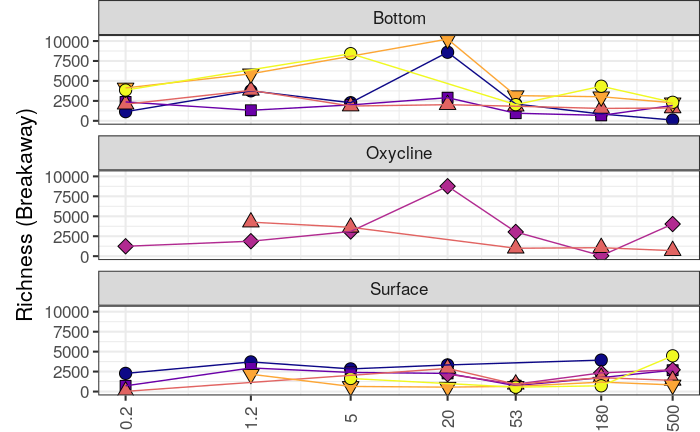

```r
plotBreak <- diversityDataWB %>%

#filter(Depth %in% c("Surface", "Bottom")) %>%
  ggplot(aes(x = Size_Class, y = break_estimate, shape = as.factor(Station), fill = as.factor(Station))) +
  plotSpecs +
  #scale_y_log10()+
  ylab("Richness (Breakaway)")
plotBreak
```

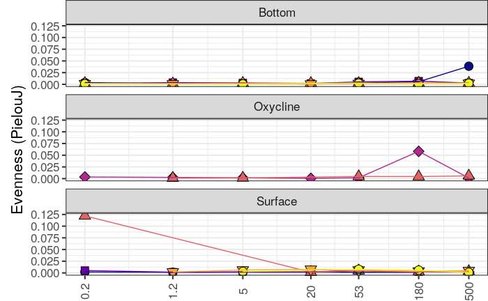

```r
plotPielou2 <- diversityDataWB %>%

#filter(Depth %in% c("Surface", "Bottom")) %>%
  ggplot(aes(x = Size_Class, y = pielouJ2, shape = as.factor(Station), fill = as.factor(Station))) +
  plotSpecs +
  #scale_y_log10()+
  ylab("Evenness (PielouJ)")
plotPielou2
```

## Redo predictions for good measure

```r
predict(pielouMod2, se.fit = TRUE)
```

```
$fit
            1             2             3             4             5             6             7             8             9            10
 1.341781e-02  1.208365e-02  1.448962e-02  1.545636e-02  1.655708e-02  9.133348e-03  1.830626e-02  8.677842e-03  1.216220e-02  5.432105e-03
           11            12            13            14            15            16            17            18            19            20
 4.097951e-03  6.503914e-03  7.470661e-03  8.571379e-03  1.147645e-03  8.996865e-03  6.921385e-04  1.056583e-02  1.830744e-03  4.965906e-04
           21            22            23            24            25            26            27            28            29            30
 2.902554e-03  3.869300e-03  4.970018e-03 -2.453716e-03  5.395505e-03  6.964467e-03  5.751314e-04  8.052762e-03  6.750208e-04 -6.591325e-04
           31            32            33            34            35            36            37            38            39            40
 1.746831e-03  2.713577e-03  3.814295e-03  3.781582e-03 -3.609439e-03  5.563472e-03 -4.064945e-03  5.808744e-03  1.244498e-03  2.316308e-03
           41            42            43            44            45            46            47            48            49            50
 3.283055e-03  4.383773e-03  4.351060e-03 -3.039962e-03  4.809259e-03  6.132949e-03 -3.495468e-03  6.378221e-03 -1.111402e-05  7.466517e-03
           51            52            53            54            55            56            57            58            59            60
 3.572554e-03  2.238400e-03  4.644363e-03  5.611110e-03  6.711828e-03  6.679115e-03 -7.119063e-04  7.137314e-03  8.461005e-03 -1.167412e-03
           61            62            63            64            65            66            67            68            69            70
 8.706277e-03  2.316941e-03  9.794572e-03  6.895073e-03  7.966883e-03  8.933629e-03  1.003435e-02  1.000163e-02  2.610613e-03  1.045983e-02
           71            72            73            74            75
 1.178352e-02  2.155107e-03  1.202880e-02  5.639461e-03  1.311709e-02

$se.fit
 [1] 0.005485776 0.006220097 0.006093788 0.004950924 0.005039065 0.005668272 0.005535066 0.005690296 0.006427591 0.003949713 0.004983954
[12] 0.004660276 0.002998998 0.003063734 0.004341868 0.003656856 0.004399627 0.004021168 0.004047202 0.005104651 0.004683767 0.003010275
[23] 0.003012266 0.004465810 0.003571123 0.003884310 0.005225638 0.005139920 0.004077327 0.005163755 0.004667622 0.002950127 0.002890092
[34] 0.003024367 0.004464741 0.003407351 0.004527687 0.003679589 0.003964015 0.004548058 0.002723971 0.002611249 0.002761666 0.004302924
[45] 0.003147265 0.003098559 0.004359567 0.003372897 0.004913960 0.004668417 0.004117178 0.005238036 0.004667496 0.002872585 0.002709344
[56] 0.002854503 0.004328066 0.003174716 0.003082244 0.004365547 0.003324768 0.004830644 0.004569681 0.005097947 0.005549425 0.004123378
[67] 0.003979484 0.004077749 0.005156495 0.004273376 0.004177639 0.005168907 0.004335577 0.005501241 0.005298224

$df
[1] 69

$residual.scale
[1] 0.01543277
```

```r
diversityDataWB$pred_pielouJ2 = predict(pielouMod2, se.fit = TRUE)$fit
diversityDataWB$se_pielouJ2 = predict(pielouMod2, se.fit = TRUE)$se.fit
```

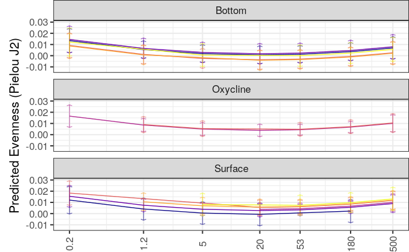

```r
plot_pielouJ2_pred <- diversityDataWB %>%

#filter(Depth %in% c("Surface", "Bottom")) %>%
  ggplot(aes(x = Size_Class, y = pred_pielouJ2, shape = as.factor(Station), fill = as.factor(Station))) +
  geom_segment(aes(y = pred_pielouJ2 - 2 * se_pielouJ2, yend = pred_pielouJ2 + 2 * se_pielouJ2, xend = Size_Class, color = as.factor(Station), alpha = 0.5), arrow = arrow(angle = 70, length = unit(0.05, "in"), ends = "both"))  +
  plotSpecs2 + ylab("Predicted Evenness (Pielou J2)") #+ scale_y_log10()
plot_pielouJ2_pred
```

## Breakaway richness subplots

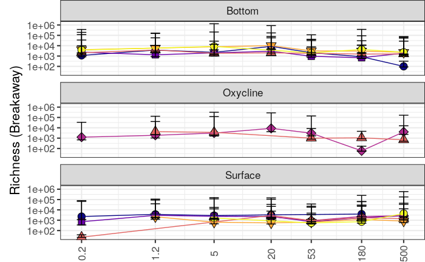

```r
plotBreakaway <- diversityDataWB %>%
#filter(Depth %in% c("Surface", "Bottom")) %>%
  ggplot(aes(x = Size_Class, y = break_estimate, shape = as.factor(Station), fill = as.factor(Station))) +
  plotSpecs +
  geom_errorbar(aes(ymin = break_lower, ymax = break_upper), width = -.1) +
  scale_y_log10() +
  ylab("Richness (Breakaway)")
plotBreakaway
```

```r
#predict(breakLm, se.fit = TRUE)
# doesn't work because built with a different data frame
```

Why are these not smooth curves?!! What if I redo the model, this time with the same data frame

```r
breakLm2 <- lm(break_estimate ~ log10(Size_Class) + I(log10(Size_Class) ^2) + Salinity +  I(Salinity^2) + log10(Oxygen + 0.03) ,data = diversityDataWB)
breakLm2 %>% summary()
```

```
Call:
lm(formula = break_estimate ~ log10(Size_Class) + I(log10(Size_Class)^2) +
    Salinity + I(Salinity^2) + log10(Oxygen + 0.03), data = diversityDataWB)

Residuals:
    Min      1Q  Median      3Q     Max
-2147.0 -1070.9  -377.8   560.4  6309.7

Coefficients:
                       Estimate Std. Error t value Pr(>|t|)
(Intercept)            3883.505    767.656   5.059 3.33e-06 ***
log10(Size_Class)       748.175    443.235   1.688   0.0959 .
I(log10(Size_Class)^2) -444.088    189.129  -2.348   0.0217 *
Salinity               -448.046    171.648  -2.610   0.0111 *
I(Salinity^2)            23.596      9.125   2.586   0.0118 *
log10(Oxygen + 0.03)    436.745    760.630   0.574   0.5677
---
Signif. codes:  0 ‘***’ 0.001 ‘**’ 0.01 ‘*’ 0.05 ‘.’ 0.1 ‘ ’ 1

Residual standard error: 1801 on 69 degrees of freedom
Multiple R-squared:  0.2306,    Adjusted R-squared:  0.1749
F-statistic: 4.137 on 5 and 69 DF,  p-value: 0.002408
```

```r
#predict(breakLm2, se.fit = TRUE)
diversityDataWB$pred_break = predict(breakLm2, se.fit = TRUE)$fit
diversityDataWB$se_break = predict(breakLm2, se.fit = TRUE)$se.fit
```

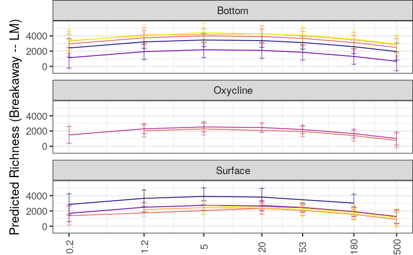

```r
plot_break_pred <- diversityDataWB %>%

#filter(Depth %in% c("Surface", "Bottom")) %>%
#  filter(Station == 4.3) %>%
  ggplot(aes(x = Size_Class, y = pred_break, shape = as.factor(Station), fill = as.factor(Station))) +
  geom_segment(aes(y = pred_break - 2 * se_break, yend = pred_break + 2 * se_break, xend = Size_Class, color = as.factor(Station), alpha = 0.5), arrow = arrow(angle = 70, length = unit(0.05, "in"), ends = "both"))  +
  plotSpecs2 + ylab("Predicted Richness (Breakaway -- LM)") #+ scale_y_log10()
plot_break_pred
```

## Rebuilding combined products

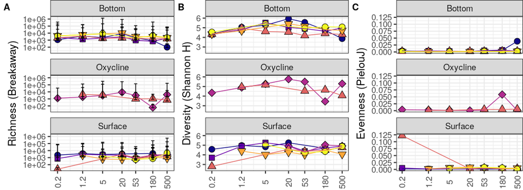

```r
plotAlphaWB <- plot_grid(plotBreakaway, plotShan, plotPielou2, nrow = 1, labels = LETTERS)
plotAlphaWB
```

```r
ggsave(here::here("Figures", "BreakawayAlpha.png"), plotAlphaWB, width = 8, height = 4)
```

Summary table I want both breakaway metrics here

```r
bettaTable <- myBet_Env$table %>%
  as.data.frame() %>%
  rename(estimate = Estimates,
         `std.error` = `Standard Errors`,
         `p.value`=`p-values`
         ) %>%
  mutate(`statistic` = NA) %>%
  rownames_to_column(var = "term") %>%
  select(term, estimate, std.error, statistic, p.value) %>%
  as_tibble()
bettaTable
```

| term | estimate | std.error | statistic | p.value |
| --- | --- | --- | --- | --- |
| (Intercept) | 3958.54016 | 238.185042 | NA | 0.000 |
| log10(Size_Class) | 652.43401 | 139.854036 | NA | 0.000 |
| I(log10(Size_Class)^2) | -396.09063 | 61.618227 | NA | 0.000 |
| Salinity | -367.84038 | 20.592837 | NA | 0.000 |
| I(Salinity^2) | 16.98352 | 1.200721 | NA | 0.000 |
| log10(Oxygen + 0.03) | -87.67167 | 312.530892 | NA | 0.779 |

```r
alphaSummary2 <- tibble(
  metric = c("Richness (Breakaway -- LM)", "Diversity (Shannon H)", "Evenness (Pielou J)"),
  model = list(breakLm_Env, shanMod, pielouMod2)
)

alphaSummary2 <- alphaSummary2 %>%
  mutate(df = map(model, ~broom::tidy(summary(.))))

## Add in willis variables

breakawaySummary <- tibble(
  metric = "Richness (Breakaway -- Betta)",
  model = NULL,
  df = list(bettaTable)
)

alphaSummary2 = bind_rows(breakawaySummary, alphaSummary2)

alphaSummary2 <- alphaSummary2 %>%
  select(-model) %>%
  unnest(df)

alphaSummary2 <- alphaSummary2 %>%
  rename(Metric = metric, Term = term, Estimate = estimate, `Standard Error` = std.error, `T Value` = statistic, p = p.value) %>%
  mutate(Term = str_replace(Term, "^I?\\((.*)\\)", "\\1"),
         Term = str_replace(Term, "\\^2", "\\^2\\^"),
         Term = str_replace(Term, "depth", "Depth"),
         Term = str_replace(Term, "lat", "Latitude"),
         Term = str_replace(Term, "sqrt\\(Size_Class\\)", "√Size Class"),
         Term = str_replace(Term, "log10", "log\\~10\\~"),
         Term = str_replace(Term, "_", " ")# BOOKMARK!!
         ) %>%
  mutate(Estimate = format(Estimate, digits = 2, scientific = TRUE) %>%
           reformat_sci()
         ) %>%
  mutate(`Standard Error` = format(`Standard Error`, digits = 2, scientific = TRUE) %>%
           reformat_sci()
  ) %>%
  mutate(`T Value` = format(`T Value`, digits = 2, scientific = FALSE)) %>%
  mutate(p = if_else(p < 0.001, "< 0.001", format(round(p, digits = 3)))) %>%
  rename(`Standard\nError` = `Standard Error`) %>%
  identity()



alphaSummary2
```

| Metric | Term | Estimate | Standard Error | T Value | p |
| --- | --- | --- | --- | --- | --- |
| Richness (Breakaway -- Betta) | Intercept | 4.0 x 10^3^ | 2.4 x 10^2^ | NA | < 0.001 |
| Richness (Breakaway -- Betta) | log~10~(Size Class) | 6.5 x 10^2^ | 1.4 x 10^2^ | NA | < 0.001 |
| Richness (Breakaway -- Betta) | log~10~(Size Class)^2^ | -4.0 x 10^2^ | 6.2 x 10^1^ | NA | < 0.001 |
| Richness (Breakaway -- Betta) | Salinity | -3.7 x 10^2^ | 2.1 x 10^1^ | NA | < 0.001 |
| Richness (Breakaway -- Betta) | Salinity^2^ | 1.7 x 10^1^ | 1.2 x 10^0^ | NA | < 0.001 |
| Richness (Breakaway -- Betta) | log~10~(Oxygen + 0.03) | -8.8 x 10^1^ | 3.1 x 10^2^ | NA | 0.779 |
| Richness (Breakaway -- LM) | Intercept | 3.9 x 10^3^ | 7.7 x 10^2^ | 5.059 | < 0.001 |
| Richness (Breakaway -- LM) | log~10~(Size Class) | 7.5 x 10^2^ | 4.4 x 10^2^ | 1.688 | 0.096 |
| Richness (Breakaway -- LM) | log~10~(Size Class)^2^ | -4.4 x 10^2^ | 1.9 x 10^2^ | -2.348 | 0.022 |
| Richness (Breakaway -- LM) | Salinity | -4.5 x 10^2^ | 1.7 x 10^2^ | -2.610 | 0.011 |

[output cut: 14 more lines]

```r
alphaTable2 <- alphaSummary2 %>% flextable() %>% merge_v(j = 1) %>% theme_vanilla() %>% bold(i = ~ p< 0.05, j = "p") %>% colformat_md() %>% set_table_properties(layout = "autofit") %>%
  align(j = -c(1:2), align = "right")
alphaTable2
```

| Metric | Term | Estimate | Standard Error | T Value | p |
| --- | --- | --- | --- | --- | --- |
| Richness (Breakaway – Betta) | Intercept | 4.0 x 103 | 2.4 x 102 | NA | < 0.001 |
|  | log10(Size Class) | 6.5 x 102 | 1.4 x 102 | NA | < 0.001 |
|  | log10(Size Class)2 | -4.0 x 102 | 6.2 x 101 | NA | < 0.001 |
|  | Salinity | -3.7 x 102 | 2.1 x 101 | NA | < 0.001 |
|  | Salinity2 | 1.7 x 101 | 1.2 x 100 | NA | < 0.001 |
|  | log10(Oxygen + 0.03) | -8.8 x 101 | 3.1 x 102 | NA | 0.779 |
| Richness (Breakaway – LM) | Intercept | 3.9 x 103 | 7.7 x 102 | 5.059 | < 0.001 |
|  | log10(Size Class) | 7.5 x 102 | 4.4 x 102 | 1.688 | 0.096 |
|  | log10(Size Class)2 | -4.4 x 102 | 1.9 x 102 | -2.348 | 0.022 |
|  | Salinity | -4.5 x 102 | 1.7 x 102 | -2.610 | 0.011 |
|  | Salinity2 | 2.4 x 101 | 9.1 x 100 | 2.586 | 0.012 |
|  | log10(Oxygen + 0.03) | 4.4 x 102 | 7.6 x 102 | 0.574 | 0.568 |
| Diversity (Shannon H) | Intercept | 5.2 x 100 | 2.0 x 10-1 | 26.613 | < 0.001 |
|  | log10(Size Class) | 5.0 x 10-1 | 1.1 x 10-1 | 4.461 | < 0.001 |
|  | log10(Size Class)2 | -2.1 x 10-1 | 4.8 x 10-2 | -4.278 | < 0.001 |
|  | Salinity | -9.5 x 10-2 | 4.4 x 10-2 | -2.175 | 0.033 |
|  | Salinity2 | 3.2 x 10-3 | 2.3 x 10-3 | 1.386 | 0.170 |
|  | log10(Oxygen + 0.03) | -1.4 x 10-1 | 1.9 x 10-1 | -0.738 | 0.463 |
| Evenness (Pielou J) | Intercept | 6.1 x 10-4 | 6.6 x 10-3 | 0.092 | 0.927 |
|  | log10(Size Class) | -8.3 x 10-3 | 3.8 x 10-3 | -2.182 | 0.033 |
|  | log10(Size Class)2 | 3.2 x 10-3 | 1.6 x 10-3 | 1.965 | 0.053 |
|  | Salinity | 1.0 x 10-3 | 1.5 x 10-3 | 0.687 | 0.494 |
|  | Salinity2 | -3.4 x 10-5 | 7.8 x 10-5 | -0.432 | 0.667 |
|  | log10(Oxygen + 0.03) | 4.8 x 10-3 | 6.5 x 10-3 | 0.738 | 0.463 |

```r
alphaTable2 %>% save_as_docx(path = here::here("Tables", "alphaTable2_Env.docx"))
```

## And finally predictions from richness, diversity evenness again.

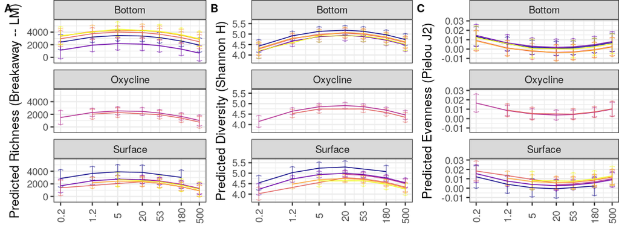

```r
plotAlphaWB_pred <- plot_grid(plot_break_pred,plotShannonH_pred,plot_pielouJ2_pred, nrow = 1, labels = LETTERS)
plotAlphaWB_pred
```

```r
ggsave(here::here("Figures", "BreakawayAlphaPredictions_Env.png"), plot = plotAlphaWB_pred, width = 8, height = 4)
```